# Using Python for Data Analysis

### Grouping Data

It's often useful to be able to group the data within a column according to the data in another column.

For example, you might wish to take the mean pedestrian counts for each month, or each year. We could do this is a complicated and time consuming way where you subset the data for each month, and then take the mean of the Counts column...or we could just use the `groupby` function. `groupby` outputs a reformatted version of your data where all values associated with your "grouping factor" are taken together. You can then perform mathematical and statistical tests on this grouped output, and the tests will be performed within each of the "groups" you defined.

The documentation for this is quite good, so I would recommend [reading it](http://pandas.pydata.org/pandas-docs/stable/groupby.html) if you'd like to learn more than what we learn here. There is also another tutorial [here](https://chrisalbon.com/python/pandas_apply_operations_to_groups.html) that covers how to apply functions to your groups in more depth.

Say that we wanted to find the mean pedestrian counts seen in each month:

```python
pdsn_no_nulls.groupby(by=["Month"])
```

```
<pandas.core.groupby.DataFrameGroupBy object at 0x000001E4DB459F60>
```

In this case, pdsn_no_nulls.groupby('Month').aggregate(mean) means "Group the rows by month and then take the mean of all of the values with the same month.

```python
month_means = pdsn_no_nulls.groupby('Month').aggregate(mean)
month_means
```

| Month | index | Hour | SensorID | PedestrianCount | Day | Year |
| --- | --- | --- | --- | --- | --- | --- |
| 1 | 351822.237092 | 11.500499 | 15.090399 | 602.167428 | 16.108778 | 2013.802022 |
| 2 | 310299.881479 | 11.485237 | 14.323410 | 641.116647 | 13.084635 | 2013.547492 |
| 3 | 243207.896902 | 11.500000 | 12.819942 | 682.660273 | 15.955470 | 2013.189739 |
| 4 | 262394.292079 | 11.500000 | 12.720792 | 657.379868 | 15.473267 | 2013.198020 |
| 5 | 279326.872957 | 11.500231 | 12.678764 | 621.398372 | 16.154492 | 2013.194434 |
| 6 | 302826.801915 | 11.500000 | 13.294060 | 579.292730 | 15.474718 | 2013.219440 |
| 7 | 316740.884403 | 11.499909 | 13.361792 | 616.520401 | 15.900030 | 2013.200730 |
| 8 | 337112.637567 | 11.500000 | 13.509564 | 615.328797 | 16.139774 | 2013.209416 |
| 9 | 348034.150839 | 11.503597 | 14.706936 | 606.965523 | 15.617322 | 2013.198284 |
| 10 | 363413.445684 | 11.509633 | 15.390438 | 618.185780 | 16.098307 | 2013.183989 |
| 11 | 382463.410987 | 11.500061 | 15.615394 | 626.704711 | 15.401457 | 2013.179034 |
| 12 | 401881.947146 | 11.499804 | 15.702233 | 649.984053 | 16.014173 | 2013.176027 |

```python
# You can see a summary of your grouped data
pdsn_no_nulls[["Day","Month","PedestrianCount"]].groupby('Month').describe()
```

| Month | Day count | Day mean | Day std | Day min | Day 25% | Day 50% | Day 75% | Day max | PedestrianCount count | PedestrianCount mean | PedestrianCount std | PedestrianCount min | PedestrianCount 25% | PedestrianCount 50% | PedestrianCount 75% | PedestrianCount max |
| --- | --- | --- | --- | --- | --- | --- | --- | --- | --- | --- | --- | --- | --- | --- | --- | --- |
| 1 | 75089.0 | 16.108778 | 8.969309 | 1.0 | 8.0 | 16.0 | 24.0 | 31.0 | 75089.0 | 602.167428 | 801.483352 | 0.0 | 66.00 | 264.0 | 810.0 | 6915.0 |
| 2 | 57104.0 | 13.084635 | 8.068940 | 1.0 | 6.0 | 12.0 | 20.0 | 29.0 | 57104.0 | 641.116647 | 829.949972 | 0.0 | 70.00 | 286.0 | 905.0 | 8592.0 |
| 3 | 49584.0 | 15.955470 | 8.945063 | 1.0 | 8.0 | 16.0 | 24.0 | 31.0 | 49584.0 | 682.660273 | 887.441844 | 0.0 | 71.00 | 286.0 | 974.0 | 9505.0 |
| 4 | 48480.0 | 15.473267 | 8.648261 | 1.0 | 8.0 | 15.0 | 23.0 | 30.0 | 48480.0 | 657.379868 | 879.174001 | 0.0 | 62.00 | 263.0 | 920.0 | 11284.0 |
| 5 | 49873.0 | 16.154492 | 8.952861 | 1.0 | 8.0 | 16.0 | 24.0 | 31.0 | 49873.0 | 621.398372 | 819.553941 | 0.0 | 57.00 | 249.0 | 899.0 | 6528.0 |
| 6 | 48888.0 | 15.474718 | 8.633686 | 1.0 | 8.0 | 15.0 | 23.0 | 30.0 | 48888.0 | 579.292730 | 789.596390 | 0.0 | 52.00 | 219.0 | 803.0 | 6692.0 |
| 7 | 49335.0 | 15.900030 | 8.927310 | 1.0 | 8.0 | 16.0 | 24.0 | 31.0 | 49335.0 | 616.520401 | 835.228811 | 0.0 | 53.00 | 238.0 | 858.0 | 9820.0 |
| 8 | 48936.0 | 16.139774 | 8.928809 | 1.0 | 8.0 | 16.0 | 24.0 | 31.0 | 48936.0 | 615.328797 | 811.560345 | 0.0 | 55.00 | 243.5 | 887.0 | 5795.0 |
| 9 | 54210.0 | 15.617322 | 8.697147 | 1.0 | 8.0 | 16.0 | 23.0 | 30.0 | 54210.0 | 606.965523 | 796.491228 | 0.0 | 59.00 | 257.0 | 852.0 | 8885.0 |
| 10 | 59172.0 | 16.098307 | 8.912805 | 1.0 | 8.0 | 16.0 | 24.0 | 31.0 | 59172.0 | 618.185780 | 789.334124 | 0.0 | 65.75 | 282.0 | 874.0 | 6566.0 |
| 11 | 57503.0 | 15.401457 | 8.635923 | 1.0 | 8.0 | 15.0 | 23.0 | 30.0 | 57503.0 | 626.704711 | 810.618870 | 0.0 | 71.00 | 279.0 | 869.0 | 6837.0 |
| 12 | 58633.0 | 16.014173 | 8.955178 | 1.0 | 8.0 | 16.0 | 24.0 | 31.0 | 58633.0 | 649.984053 | 878.019136 | 0.0 | 70.00 | 272.0 | 881.0 | 6656.0 |

```python
month_means.index = ["January", "February","March","April","May","June",\
                     "July","August","September","October","November","December"]
del month_means["index"]

month_means
```

|  | Hour | SensorID | PedestrianCount | Day | Year |
| --- | --- | --- | --- | --- | --- |
| January | 11.500499 | 15.090399 | 602.167428 | 16.108778 | 2013.802022 |
| February | 11.485237 | 14.323410 | 641.116647 | 13.084635 | 2013.547492 |
| March | 11.500000 | 12.819942 | 682.660273 | 15.955470 | 2013.189739 |
| April | 11.500000 | 12.720792 | 657.379868 | 15.473267 | 2013.198020 |
| May | 11.500231 | 12.678764 | 621.398372 | 16.154492 | 2013.194434 |
| June | 11.500000 | 13.294060 | 579.292730 | 15.474718 | 2013.219440 |
| July | 11.499909 | 13.361792 | 616.520401 | 15.900030 | 2013.200730 |
| August | 11.500000 | 13.509564 | 615.328797 | 16.139774 | 2013.209416 |
| September | 11.503597 | 14.706936 | 606.965523 | 15.617322 | 2013.198284 |
| October | 11.509633 | 15.390438 | 618.185780 | 16.098307 | 2013.183989 |
| November | 11.500061 | 15.615394 | 626.704711 | 15.401457 | 2013.179034 |
| December | 11.499804 | 15.702233 | 649.984053 | 16.014173 | 2013.176027 |

```python
month_means.describe()
```

|  | Hour | SensorID | PedestrianCount | Day | Year |
| --- | --- | --- | --- | --- | --- |
| count | 12.000000 | 12.000000 | 12.000000 | 12.000000 | 12.000000 |
| mean | 11.499914 | 14.101144 | 626.475382 | 15.618535 | 2013.274886 |
| std | 0.005427 | 1.168983 | 27.624860 | 0.846829 | 0.194882 |
| min | 11.485237 | 12.678764 | 579.292730 | 13.084635 | 2013.176027 |
| 25% | 11.499977 | 13.175530 | 613.237978 | 15.474355 | 2013.188301 |
| 50% | 11.500000 | 13.916487 | 619.792076 | 15.927750 | 2013.198152 |
| 75% | 11.500298 | 15.165409 | 643.333498 | 16.100924 | 2013.211922 |
| max | 11.509633 | 15.702233 | 682.660273 | 16.154492 | 2013.802022 |

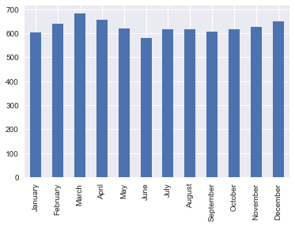

```python
month_means["PedestrianCount"].plot(kind='bar')
```

```python
# Can also specificy multiple columns to be output
    # the mean "Hour" and pedestrian counts within each month
pdsn.groupby(by=["Month"]).mean()[["PedestrianCount","Hour"]]
```

| Month | PedestrianCount | Hour |
| --- | --- | --- |
| 1 | 602.159875 | 11.500000 |
| 2 | 641.116647 | 11.485237 |
| 3 | 682.660273 | 11.500000 |
| 4 | 657.379868 | 11.500000 |
| 5 | 621.398372 | 11.500231 |
| 6 | 579.292730 | 11.500000 |
| 7 | 616.508108 | 11.500000 |
| 8 | 615.328797 | 11.500000 |
| 9 | 606.965523 | 11.503597 |
| 10 | 618.185780 | 11.509633 |
| 11 | 626.704711 | 11.500061 |
| 12 | 649.984053 | 11.499804 |

You can also choose to group over multiple factors, such as by Month and Year together, by specifying a list for the `by` parameter within `groupby()`. The order of the values in this list matters, as `groupby` will first group your data based on the first factor, and THEN the second factor.

```python
# Grouping by Year, then by month
#The average number of pedestrians
pdsn.groupby(by=["Year","Month"]).mean()
```

| Year | Month | Hour | SensorID | PedestrianCount | Day |
| --- | --- | --- | --- | --- | --- |
| 2012 | 1 | 11.500000 | 9.499739 | 593.880024 | 16.000000 |
|  | 2 | 11.500000 | 9.500000 | 664.069604 | 15.000000 |
|  | 3 | 11.500000 | 9.500000 | 708.321087 | 16.000000 |
|  | 4 | 11.500000 | 9.500000 | 662.224460 | 15.500000 |
|  | 5 | 11.500000 | 9.500000 | 640.853569 | 16.000000 |
|  | 6 | 11.500000 | 9.500000 | 608.292438 | 15.500000 |
|  | 7 | 11.500000 | 9.500000 | 653.820266 | 16.000000 |
|  | 8 | 11.500000 | 9.500000 | 633.853719 | 16.000000 |
|  | 9 | 11.499405 | 9.344204 | 641.173530 | 15.616282 |
|  | 10 | 11.500000 | 9.500000 | 653.699671 | 16.000000 |
|  | 11 | 11.500000 | 9.500000 | 652.947454 | 15.500000 |
|  | 12 | 11.500000 | 9.389397 | 677.285878 | 15.798903 |
| 2013 | 1 | 11.500000 | 9.348066 | 614.056783 | 16.220994 |
|  | 2 | 11.500000 | 9.500000 | 658.246445 | 14.500000 |
|  | 3 | 11.500000 | 9.500000 | 667.956467 | 16.000000 |
|  | 4 | 11.500000 | 9.500000 | 658.531867 | 15.500000 |
|  | 5 | 11.500000 | 9.500000 | 625.939964 | 16.000000 |
|  | 6 | 11.500000 | 9.176471 | 591.016422 | 15.500000 |
|  | 7 | 11.500000 | 9.176471 | 639.931293 | 16.000000 |
|  | 8 | 11.500000 | 9.000000 | 644.591230 | 16.000000 |
|  | 9 | 11.511093 | 13.839167 | 621.340619 | 15.779293 |
|  | 10 | 11.511930 | 15.626715 | 607.113297 | 16.366402 |
|  | 11 | 11.500000 | 15.930101 | 638.762026 | 15.391206 |
|  | 12 | 11.500000 | 15.988030 | 661.754761 | 16.302503 |
| 2014 | 1 | 11.500000 | 16.468150 | 591.552915 | 16.012133 |
|  | 2 | 11.500000 | 16.413832 | 646.541572 | 14.367347 |
|  | 3 | 11.500000 | 16.720000 | 676.224474 | 15.903158 |
|  | 4 | 11.500000 | 16.421277 | 653.935018 | 15.442553 |
|  | 5 | 11.500498 | 16.366235 | 607.479839 | 16.333709 |
|  | 6 | 11.500000 | 17.497467 | 557.368794 | 15.447822 |
|  | 7 | 11.500000 | 17.855255 | 582.341690 | 15.790937 |
|  | 8 | 11.500000 | 18.051777 | 590.099281 | 16.289340 |
|  | 9 | 11.500000 | 18.279548 | 577.266101 | 15.491264 |
|  | 10 | 11.512912 | 18.430290 | 608.402323 | 15.915112 |
|  | 11 | 11.500151 | 18.735412 | 601.042184 | 15.355923 |
|  | 12 | 11.499510 | 18.967675 | 623.627575 | 15.863491 |
| 2015 | 1 | 11.500000 | 19.781521 | 610.483598 | 16.196343 |
|  | 2 | 11.425477 | 20.911245 | 587.227723 | 7.049593 |

```python
pdsn.groupby(by=["Month","Year"]).mean()
```

| Month | Year | Hour | SensorID | PedestrianCount | Day |
| --- | --- | --- | --- | --- | --- |
| 1 | 2012 | 11.500000 | 9.499739 | 593.880024 | 16.000000 |
|  | 2013 | 11.500000 | 9.348066 | 614.056783 | 16.220994 |
|  | 2014 | 11.500000 | 16.468150 | 591.552915 | 16.012133 |
|  | 2015 | 11.500000 | 19.781521 | 610.483598 | 16.196343 |
| 2 | 2012 | 11.500000 | 9.500000 | 664.069604 | 15.000000 |
|  | 2013 | 11.500000 | 9.500000 | 658.246445 | 14.500000 |
|  | 2014 | 11.500000 | 16.413832 | 646.541572 | 14.367347 |
|  | 2015 | 11.425477 | 20.911245 | 587.227723 | 7.049593 |
| 3 | 2012 | 11.500000 | 9.500000 | 708.321087 | 16.000000 |
|  | 2013 | 11.500000 | 9.500000 | 667.956467 | 16.000000 |
|  | 2014 | 11.500000 | 16.720000 | 676.224474 | 15.903158 |
| 4 | 2012 | 11.500000 | 9.500000 | 662.224460 | 15.500000 |
|  | 2013 | 11.500000 | 9.500000 | 658.531867 | 15.500000 |
|  | 2014 | 11.500000 | 16.421277 | 653.935018 | 15.442553 |
| 5 | 2012 | 11.500000 | 9.500000 | 640.853569 | 16.000000 |
|  | 2013 | 11.500000 | 9.500000 | 625.939964 | 16.000000 |
|  | 2014 | 11.500498 | 16.366235 | 607.479839 | 16.333709 |
| 6 | 2012 | 11.500000 | 9.500000 | 608.292438 | 15.500000 |
|  | 2013 | 11.500000 | 9.176471 | 591.016422 | 15.500000 |
|  | 2014 | 11.500000 | 17.497467 | 557.368794 | 15.447822 |
| 7 | 2012 | 11.500000 | 9.500000 | 653.820266 | 16.000000 |
|  | 2013 | 11.500000 | 9.176471 | 639.931293 | 16.000000 |
|  | 2014 | 11.500000 | 17.855255 | 582.341690 | 15.790937 |
| 8 | 2012 | 11.500000 | 9.500000 | 633.853719 | 16.000000 |
|  | 2013 | 11.500000 | 9.000000 | 644.591230 | 16.000000 |
|  | 2014 | 11.500000 | 18.051777 | 590.099281 | 16.289340 |
| 9 | 2012 | 11.499405 | 9.344204 | 641.173530 | 15.616282 |
|  | 2013 | 11.511093 | 13.839167 | 621.340619 | 15.779293 |
|  | 2014 | 11.500000 | 18.279548 | 577.266101 | 15.491264 |
| 10 | 2012 | 11.500000 | 9.500000 | 653.699671 | 16.000000 |
|  | 2013 | 11.511930 | 15.626715 | 607.113297 | 16.366402 |
|  | 2014 | 11.512912 | 18.430290 | 608.402323 | 15.915112 |
| 11 | 2012 | 11.500000 | 9.500000 | 652.947454 | 15.500000 |
|  | 2013 | 11.500000 | 15.930101 | 638.762026 | 15.391206 |
|  | 2014 | 11.500151 | 18.735412 | 601.042184 | 15.355923 |
| 12 | 2012 | 11.500000 | 9.389397 | 677.285878 | 15.798903 |
|  | 2013 | 11.500000 | 15.988030 | 661.754761 | 16.302503 |
|  | 2014 | 11.499510 | 18.967675 | 623.627575 | 15.863491 |

```python
pdsn.columns
```

```
Index(['Date', 'Day_of_week', 'Hour', 'SensorID', 'SensorName',
       'PedestrianCount', 'Day', 'Month', 'Year'],
      dtype='object')
```

By chaining more commands together you can also find the maximum, minimum, etc, values for your groups

```python
# Minimum
pdsn.groupby(by=["Month"]).PedestrianCount.sum().min()
```

```
28320463.0
```

But which month is this associated with?

```python
# Finding the Month associated with the minimum value
countMin = pdsn.groupby(by=["Month"]).PedestrianCount.sum().min()

pdsn.groupby(by=["Month"]).PedestrianCount.sum()[pdsn.groupby(by=["Month"]).PedestrianCount.sum() == countMin]
```

```
Month
6    28320463.0
Name: PedestrianCount, dtype: float64
```

You can also iterate over your groups using a `for` loop, just as if you were using a dictionary:

```python
for name, group in pdsn[['Day_of_week',"SensorName"]].groupby(by = 'Day_of_week'):
    print(name)
    print(group)
```

```
Friday
       Day_of_week                              SensorName
2160        Friday                        Town Hall (West)
2161        Friday                   Collins Place (South)
2162        Friday                   Collins Place (North)
2163        Friday                    Australia on Collins
2164        Friday              Bourke Street Mall (South)
2165        Friday              Bourke Street Mall (North)
2166        Friday                       Flagstaff Station
2167        Friday                       Melbourne Central
2168        Friday                           State Library
2169        Friday                  Southern Cross Station
2170        Friday                          Victoria Point
2171        Friday                                New Quay
2172        Friday                         Waterfront City
```

[output cut: 161 more lines]

**limit_output extension: Maximum message size of 10000 exceeded with 25845 characters**

#### Challenge

Which sensor has the greatest average Pedestrian traffic?

#### Optional Challenge

```python
df_vet.groupby('animal')['age'].mean()
```

```
animal
cat      2.5
dog      5.0
snake    2.5
Name: age, dtype: float64
```

## Plotting Your Data

This section will teach you the basics of plotting within Seaborn. Seaborn builds upon matplotlib, and so you'll be learning how to use both Seaborn and matplotlib functions at the same time.

This is hardly comprehensive, and there's a wide array of customisability and control with matplotlib and plotly. Feel free to delve into some of user guides and tutorials and questions available on Google and Stack Overflow to learn more about these tools and how to make them work for you.

*Seaborn tutorials*:

- https://seaborn.pydata.org/
- https://seaborn.pydata.org/examples/index.html#example-gallery
- https://elitedatascience.com/python-seaborn-tutorial

*Matpotlib*:

- https://matplotlib.org/users/pyplot_tutorial.html
- The [matplotlib API](https://matplotlib.org/devdocs/api/_as_gen/matplotlib.pyplot.html) contains all of the functions you can call within matplotlib, along with detailed information about how you can use them and their parameters
- A handy "quick guide" to the different kinds of plotting functions within pyplot can also be found at the [pyplot API](https://matplotlib.org/api/pyplot_api.html)

Let's begin by trying to plot the data

```python
pdsn.groupby(by = "Month").plot()
```

Matplotlib.pyplot has great customisability, so let's play around with trying to plot different types of graphs with our data

### Line Plot

Line plots are great for plotting series data, usually a time series of some description.

Line plots are the default plot drawn when calling `.plot()`.

Within the plot function you can also specify the Figure title and the figure size

```python
# Line plot
pdsn.groupby(by = ['Year', 'Month']).mean().Counts.plot( # Drawing a pot from the grouped Year, Month data
                                                figsize = (8,6), # The figure size
                                                title = 'Mean Pedestrian Counts per Month, per Year') #Figure Title

#specifying the x-axis label
plt.xlabel('Pedestrian Counts per Year, Month')

# the y-axis label
plt.ylabel('Counts (mean)')

#Rotating the x-axis labels
plt.xticks(rotation=90)

#If you want to SAVE your plot, make sure you do it BEFORE you show it in the notebook
plt.savefig('PedestrianHistogram.png', dpi=300)

#Generating an image
plt.show()
```

### Simple scatter plots

Unfortunately our pedestrian data doesn't have many continuous variables, so our scatter plots will look rather sparse.

```python
pdsn.columns
```

```
Index(['Date', 'Day_of_week', 'Hour', 'SensorID', 'SensorName',
       'PedestrianCount', 'Day', 'Month', 'Year'],
      dtype='object')
```

```
(0, 12.703898249090692)
```

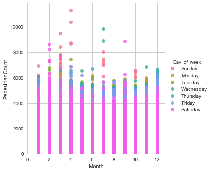

```python
# lmplot = Linear model plot
sns.lmplot(x='Month', y='PedestrianCount', data=pdsn,
         fit_reg=False, # No regression line
         hue='Day_of_week',

          )


# # Tweak using Matplotlib
plt.ylim(0, None)
plt.xlim(0, None)
```

### Boxplot

The humble boxplot is often extremely useful for conveying large amounts of information all at once

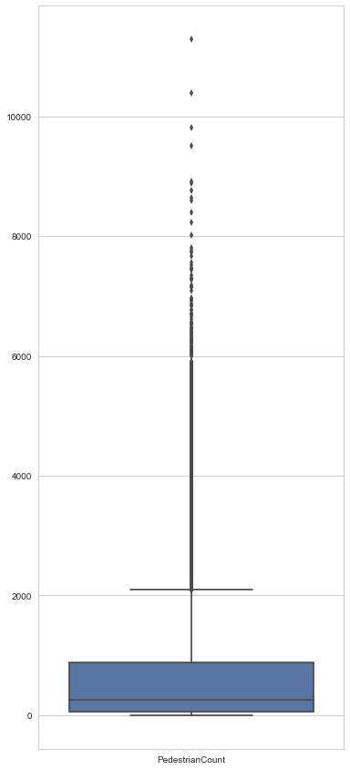

```python
# Set theme
sns.set_style('whitegrid')

#Change the size
plt.figure(figsize=(6,15))

# sns.boxplot(data = df)
sns.boxplot(data=pdsn[['PedestrianCount']]) #Can also add more boxes
```

### Violin Plot

These are like boxplots, but allows the audience to visualise exactly where the most data is occuring within your plots. Unlike boxplots, these are also much easier to plot your categorical and continuous variables against one another

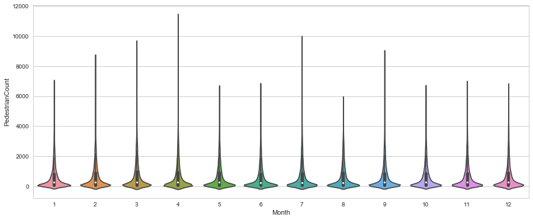

```python
plt.figure(figsize=(15,6))

# Violin plot
sns.violinplot(x='Month', y='PedestrianCount', data=pdsn)
```

### Histograms

We also cannot forget the humble histogram - these are perfect for trying to count the frequency or density of certain occurences

Be aware though! This is one of those functions that **will not** allow NaN values while plotting

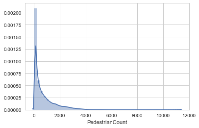

```python
#Distribution Plot (Histogram)

sns.distplot(pdsn_no_nulls.PedestrianCount)
```

### Bar Plots

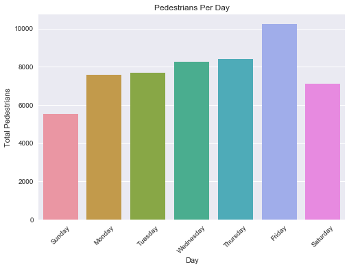

```python
# Count Plot (Bar Plot)
# when you want to show the number of observations in each category

# plt.figure(figsize=(15,6))

sns.countplot(x=pdsn[pdsn.PedestrianCount > 2000].Day_of_week, data=pdsn)

plt.title("Pedestrians Per Day")
plt.xlabel("Day")
plt.ylabel("Total Pedestrians")

# Rotate x-labels
plt.xticks(rotation=+45)

plt.show()
```

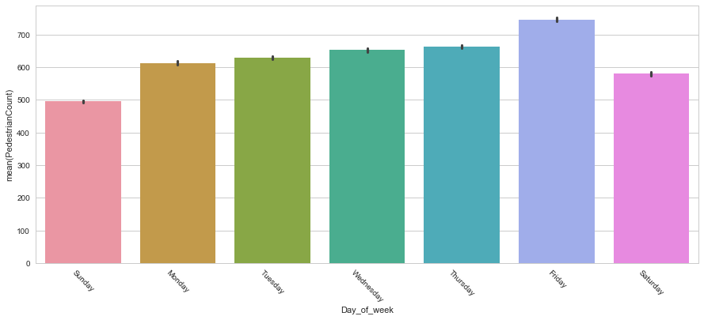

```python
#bar plots will automatically calculate a statistic for you
plt.figure(figsize=(15,6))

sns.barplot(x='Day_of_week', y="PedestrianCount", data=pdsn)

plt.xticks(rotation=-45)
```

### Heatmaps

Plotting correlation calculations

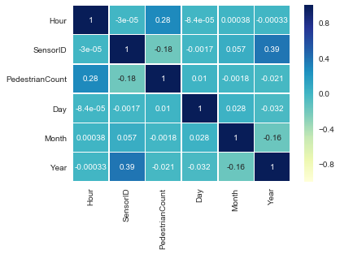

```python
# Calculate correlations
corr = pdsn.corr()

# Heatmap
sns.heatmap(corr,
            annot = True,
            linewidths=.5,
            cmap="YlGnBu"
           )
```

### Density Plot

```python
# Density Plot - this one requires two continuous variables
sns.kdeplot(x = , y = )
```

### Pairplots

Allows you to plot many different types of plots and correlations between your different variables in a single image

```python
#This one uses density plots within it, so also requires continuous data
sns.pairplot(pdsn, hue="Day_of_week", size=2.5)
```

```python
# We can make pairplots but change what we want to see in the upper, lower and diagonal quadrants

g = sns.PairGrid(pdsn)
g.map_upper(plt.scatter)
g.map_lower(sns.kdeplot, cmap="Blues_d")
g.map_diag(sns.kdeplot, lw=3, legend=False);
```

This is only a taster of what's available, and the level of customisability you're able to use for your plotting tools.

Along with those tutorials seen previously, you can also find a range of different plots - along with the accompanying code - at this [python graph gallery](https://python-graph-gallery.com).

In addition, pandas itself contains a whole range of plotting tools that are designed to work specifically with dataframes. You can see exampes of these and many more inside the pandas documentation, https://pandas.pydata.org/pandas-docs/stable/visualization.html

## Summary

This session has taken you through the beginner's guide of how to visualise, clean and investigate your data, and given you the basic tools to answer your own research questions about your data.

Python is a very versatile tool, and can go much further than what we've shown you today. Many packages are open source and being developed for a range of purposes all the time. Scipy allows you to perform basic math and statistical tests for example, there are a host of packages related to investigating biological data.

Using a programming language allows you to investigate much larger data than you can do by hand or by eye, and the customisability of the plotting tools makes it ideal for generating useful and professional images ideal for publication.

Follow us on Twitter to keep up-to-date on new and up-coming trainings

- [@ResBaz](https://twitter.com/resbaz)
- [@ResPlat](https://twitter.com/resplat)

There's also a reasonably new facebook group, called "Data Wrangling with Python" where you can post your python problems, cool things you've done, and stay apprised of new trainings coming up as well.

Also remember that if you're having problems, Research Platforms runs a weekly Hacky Hour, where anybody and everybody is able to enquire about coding and programming problems in a variety of tools. Every Thursday from 3-4pm, at the large table in Tsubu Bar.